# Migrations et Instabilité Sociale en Afrique Subsaharienne

Une analyse par économétrie spatiale — Dynamic Spatial Durbin Model (1996–2024)

Auteur·rice

M1 Économétrie Spatiale 2025

Date de publication

12 avril 2026

# Résumé

**Abstract**

**Mots-clés :** Migrations · Conflits armés · Économétrie spatiale · DSDM · Spillovers · Afrique subsaharienne

40

Pays ASS

29

Années

1 160

Observations

3

Tests robustesse

# 1 Introduction

**Première loi de la géographie — Tobler (1979)**

*« Everything depends on everything else, but closer things more so. »*

Cette loi s’applique directement aux conflits armés : un pays en guerre influence l’instabilité de ses voisins via les flux de réfugiés, la porosité des frontières et la diffusion des groupes armés.

L’Afrique subsaharienne concentre une part disproportionnée des conflits armés mondiaux. Entre 1996 et 2024, la région a connu une intensification des tensions dans le **Sahel**, la **Corne de l’Afrique** et la région des **Grands Lacs**, souvent accompagnée de déplacements massifs de populations.

Sur le plan économétrique, l’analyse de ce phénomène pose un problème fondamental : les observations spatiales violent l’**hypothèse H3c des MCO** (non-corrélation des erreurs). Les résidus de pays voisins tendent à être corrélés, rendant les estimateurs MCO biaisés ou inefficients selon le type de dépendance spatiale.

**Positionnement de ce travail**

Ce travail s’inscrit dans la continuité de **Zallé & Ouédraogo (2021)** qui analysent les spillovers de corruption et de démocratie sur les IDE en ASS via un DSDM sur 43 pays (1996–2018). Nous adoptons exactement la même structure économétrique, en remplaçant leurs variables d’intérêt par les **migrations** et les **conflits armés**.

# 2 Revue de Littérature

## 2.1 Spillovers spatiaux et dépendance géographique

La notion de spillover géographique désigne les effets de débordement par lesquels les conditions économiques ou politiques d’une unité spatiale influencent les résultats des unités voisines. Trois courants structurent notre revue.

**Courant 1 — Spillovers économiques.** Baumont, Ertur & Le Gallo (2006) montrent que la croissance régionale présente des effets de spillover significatifs en Europe. Blonigen et al. (2007) documentent des spillovers d’attractivité des IDE entre pays voisins.

**Courant 2 — Spillovers institutionnels.** Zallé & Ouédraogo (2021) montrent que la corruption et la démocratie se diffusent spatialement entre pays d’ASS. C’est notre modèle de référence direct.

**Courant 3 — Conflits et migrations.** La relation est bidirectionnelle dans la littérature. Les conflits génèrent des déplacements massifs, mais les migrations exercent également une pression sur les ressources des pays d’accueil, créant des tensions susceptibles de se diffuser spatialement.

## 2.2 Contribution

**Notre contribution originale**

Notre contribution est double : (1) nous mobilisons l’économétrie spatiale pour **quantifier les spillovers** des migrations vers les conflits, et (2) nous couvrons **1996–2024**, permettant de capturer la montée du jihadisme sahélien post-2011.

# 3 Données et Analyse Exploratoire

## 3.1 Sources de données

Table 1: T1 — Sources des données

| Variable | Type | Source | Code | Période |
| --- | --- | --- | --- | --- |
| **Conflits armés (Y)** | Var. dépendante | UCDP GED | Événements violents | 1996–2024 |
| **Stock migrants** | Var. clé | WDI | SM.POP.TOTL | 1996–2024 |
| PIB/habitant | Contrôle | WDI | NY.GDP.PCAP.KD | 1996–2024 |
| Démocratie | Contrôle institutionnel | Polity V | polity2 (-10/+10) | 1996–2024 |
| Ressources naturelles | Contrôle | WDI | NY.GDP.TOTL.RT.ZS | 1996–2024 |

**Transformations appliquées**

- **Normalisation de Y** : conflits / population × 100 000 — comparabilité entre pays (Nigeria 200M hab vs São Tomé 200k hab)
- **Forme log-log** : `log(conflits_pc + 1)` et `log(migrants + 1)` — coefficients interprétables comme élasticités
- **Variables retardées t-1** : toutes les variables explicatives — résout l’endogénéité (Zallé, 2021)

## 3.2 Statistiques descriptives

Table 2: T2 — Statistiques descriptives (Panel 40 pays × 29 années)

| Variable | Moyenne | Écart-type | Min | Max | N |
| --- | --- | --- | --- | --- | --- |
| Log conflits pc | 0.136 | 0.300 | 0.000 | 2.395 | 1160 |
| Log migrants | 12.387 | 1.256 | 8.416 | 14.967 | 1000 |
| Log PIB/hab | 6.984 | 0.864 | 5.370 | 9.476 | 1160 |
| Log ressources naturelles | 2.314 | 0.763 | 0.228 | 4.495 | 1160 |
| Démocratie (Polity2) | 1.404 | 4.769 | -7.000 | 9.000 | 1160 |

## 3.3 Analyse Exploratoire des Données Spatiales (ESDA)

**Objectif de l’ESDA**

### 3.3.1 Cartes choroplèthes

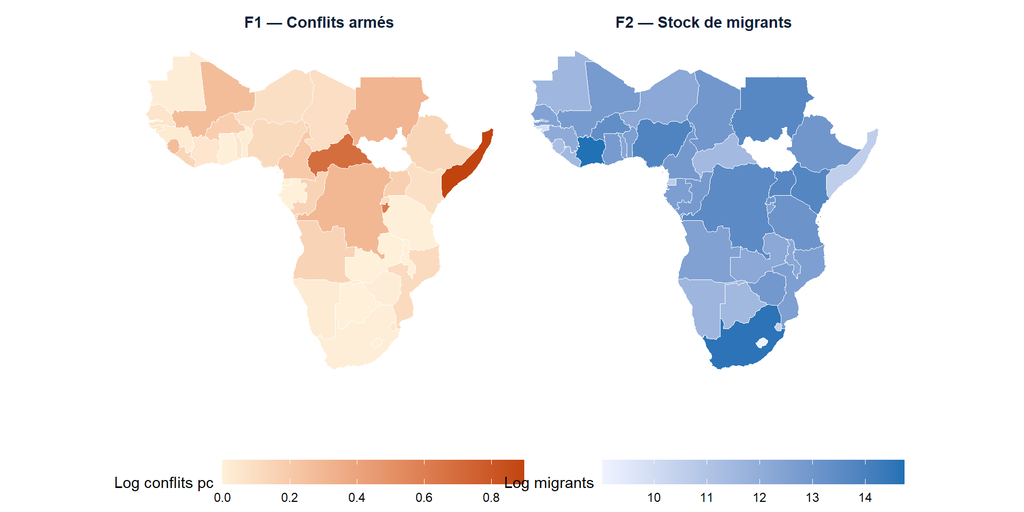

Figure 1: F1-F2 — Intensité des conflits et stock de migrants (moyenne 1996–2024)

### 3.3.2 Distribution et outliers

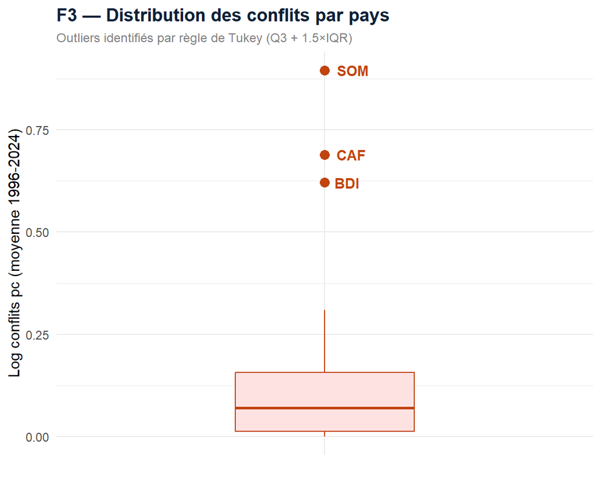

Figure 2: F3 — Distribution des conflits par pays (règle de Tukey Q3 + 1.5×IQR)

**Lecture du boxplot F3**

# 4 Méthodologie

## 4.1 Spécification du modèle DSDM

**Le modèle DSDM — Zallé & Ouédraogo (2021)**

$$\text{Conflits}_{it} = \tau \cdot \text{Conflits}_{i,t-1} + \rho \cdot W \cdot \text{Conflits}_{jt} + \beta_1 \text{Migrants}_{i,t-1} + \theta_1 W \cdot \text{Migrants}_{j,t-1} + \mathbf{X}_{it}\boldsymbol{\beta} + \mu_i + \varepsilon_{it}$$

- **τ** = persistence temporelle des conflits
- **ρ** = autocorrélation spatiale endogène
- **θ₁** = effet contextuel (spillover migrations → conflits voisins)
- **μᵢ** = effets fixes pays
- **W** = matrice de pondérations standardisée en ligne

## 4.2 Pourquoi le SDM et pas le SAR ou le SEM ?

Table 3: Comparaison des modèles spatiaux

| Critère | SAR | SEM | **SDM** |
| --- | --- | --- | --- |
| Effets indirects | Contraint à zéro | **Nuls** | **Libres** |
| Robustesse autocorr. résiduelle | Non | Oui | **Oui** |
| Estimateur MCO | Biaisé | Convergent | Biaisé (ML requis) |
| Spillovers quantifiables | Partiellement | **Non** | **Oui** |

**Justification du SDM — Elhorst (2012)**

*« Le SDM est robuste à la présence d’autocorrélation résiduelle et ne restreint pas a priori les effets indirects à zéro, contrairement au SAR. »*

## 4.3 Matrice de pondérations W

Trois matrices W sont construites, suivant Zallé & Ouédraogo (2021) :

Table 4: Construction des matrices W

| Matrice | Type | Rôle | Formule |
| --- | --- | --- | --- |
| **W1** | Contiguïté reine | **Principale** | wᵢⱼ = 1 si frontière commune |
| **W2** | Inverse-distance | Robustesse R1 | wᵢⱼ = min(d)/dᵢⱼ |
| **W3** | k=5 plus proches | Robustesse R1 | 5 voisins les plus proches |

## 4.4 Protocole d’estimation — Elhorst (2012)

①

MCO + Moran

Test dépendance spatiale sur résidus

②

Tests LM

LM-lag vs LM-err → choix SAR/SEM/SDM

③

SDM → DSDM

Estimation ML + lag temporel Y(t-1)

④

Tests Wald

Confirmer SDM vs SAR vs SEM

# 5 Résultats

## 5.1 Tests de spécification

Table 5: T3 — Tests de spécification spatiale

[output not shown]

**Lecture des tests LM**

## 5.2 Résultats du DSDM principal

Table 6: T4 — Résultats du DSDM (variable dépendante : Log conflits pc)

| Variable | Coefficient | Std. Error | z-stat | Sig |
| --- | --- | --- | --- | --- |
| ρ — Spatial lag Y | -0.0224 | 0.0338 | -0.664 |  |
| τ — Conflits (t-1) | 0.7362 | 0.0201 | 36.569 | *** |
| Log migrants (t-1) | 0.0052 | 0.0128 | 0.409 |  |
| Log PIB/hab | 0.0239 | 0.0274 | 0.874 |  |
| Démocratie (Polity2) | -0.0096 | 0.0025 | -3.817 | *** |
| Log ressources naturelles | 0.0326 | 0.0151 | 2.163 | * |
| W × Log migrants ★ | 0.0477 | 0.0229 | 2.083 | * |
| W × Log PIB/hab | 0.0228 | 0.0365 | 0.626 |  |
| W × Démocratie | -0.0004 | 0.0039 | -0.094 |  |
| W × Log ressources | -0.0290 | 0.0229 | -1.268 |  |

**Interprétation des résultats clés**

**τ = 0.736 (p < 0.001)** — Les conflits sont fortement persistants dans le temps : 73.6% de l’intensité des conflits de l’année précédente se répercute sur l’année courante.

**β₃ (polity2) = -0.0096 (p < 0.001)** — La démocratie réduit les conflits, cohérent avec la théorie de la paix démocratique.

## 5.3 Décomposition des effets directs, indirects et totaux

**Rappel conceptuel — LeSage & Pace (2009)**

- **Effet direct** = impact de X_i sur les conflits du **même pays i** (+ feedbacks)
- **Effet indirect** = impact de X_i sur les conflits des **pays voisins** = spillover géographique
- **Effet total** = Direct + Indirect = impact dans tout le système

⚠️ **Les colonnes Main (β) et Wx (θ) du tableau T4 NE SONT PAS les effets directs et indirects.** Ce sont les paramètres bruts. Les effets réels sont ci-dessous.

Table 7: T5 — Décomposition des effets directs, indirects et totaux (1 000 simulations MCMC)

| Variable | Direct | Indirect (spillover) Indirect | Total |
| --- | --- | --- | --- |
| Log migrants (t-1) | -0.0335 (-1.177) | 0.0341 (0.639) | 5e-04 (0.039) |
| Log PIB/hab | -0.1034** (-2.28) | -0.0209 (-0.303) | -0.1243** (-2.464) |
| Démocratie (Polity2) | -0.001 (-0.138) | -0.0246* (-1.65) | -0.0256 (-1.442) |
| Log ressources naturelles | 7e-04 (-0.014) | 0.0257 (0.322) | 0.0264 (0.277) |

Note :  
z-statistics entre parenthèses. Calculés via impacts() avec 1 000 simulations MCMC. *** p<0.01 ** p<0.05 * p<0.10

# 6 Tests de Robustesse

**Stratégie de robustesse — Zallé & Ouédraogo (2021)**

Suivant notre modèle de référence, nous procédons à **trois tests de robustesse** : changement de matrice W (R1), mesure alternative de Y (R2), estimateur alternatif GMM (R3).

## 6.1 R1 — Matrices W alternatives

Table 8: T6 — Robustesse R1 : Matrices W alternatives

| Variable | W1 — Contiguïté (principal) | W2 — Distance inverse | W3 — k=5 voisins |
| --- | --- | --- | --- |
| ρ (spatial lag Y) | -0.0224 (-0.665) | -0.116 (-1.408) | -0.003 (-0.077) |
| NA | 0.7362*** (36.569) | NA | NA |
| Log migrants (t-1) | 0.0052 (0.409) | 0.004 (0.314) | 5e-04 (0.038) |
| Log PIB/hab | 0.0239 (0.874) | 0.0132 (0.475) | 0.0107 (0.383) |
| Démocratie | -0.0096*** (-3.817) | -0.0094*** (-3.61) | -0.0095*** (-3.784) |
| Log ressources | 0.0326** (2.162) | 0.0318** (2.086) | 0.0331** (2.184) |
| W × Log migrants | 0.0477** (2.083) | 0.0862** (2.088) | 0.0686*** (2.963) |
| W × Log PIB/hab | 0.0228 (0.626) | 0.0039 (0.055) | 0.0523 (1.253) |
| W × Démocratie | -4e-04 (-0.094) | -0.0032 (-0.429) | -0.0024 (-0.539) |
| W × Log ressources | -0.029 (-1.268) | -0.0351 (-0.981) | -0.02 (-0.773) |
| τ — Conflits (t-1) | NA | 0.7388*** (37.679) | 0.7291*** (36.465) |

Note :  
*** p<0.01 ** p<0.05 * p<0.10 | z-statistics entre parenthèses

## 6.2 R2 — Variable dépendante alternative

Table 9: T7 — Robustesse R2 : Log décès vs Log conflits

| Variable | Modèle principal (Log conflits) | R2 — Log décès |
| --- | --- | --- |
| ρ (spatial lag Y) | -0.0224 (-0.665) | -0.0277 (-0.795) |
| NA | 0.7362*** (36.569) | NA |
| Log migrants (t-1) | 0.0052 (0.409) | 0.0311 (0.669) |
| Log PIB/hab | 0.0239 (0.874) | 0.0696 (0.697) |
| Démocratie | -0.0096*** (-3.817) | -0.0387*** (-4.228) |
| Log ressources | 0.0326** (2.162) | 0.142*** (2.615) |
| W × Log migrants | 0.0477** (2.083) | 0.221*** (2.696) |
| W × Log PIB/hab | 0.0228 (0.626) | -0.0713 (-0.537) |
| W × Démocratie | -4e-04 (-0.094) | -0.0176 (-1.233) |
| W × Log ressources | -0.029 (-1.268) | -0.1043 (-1.262) |
| τ — Conflits (t-1) | NA | 0.6216*** (28.423) |

Note :  
*** p<0.01 ** p<0.05 * p<0.10 | z-statistics entre parenthèses

## 6.3 R3 — Estimateur GMM Blundell-Bond

Table 10: T8 — Robustesse R3 : Estimateur GMM Blundell-Bond (1998)

| Variable | Coefficient | Std. Error | z-stat | p-value | ...6 |
| --- | --- | --- | --- | --- | --- |
| τ — Conflits (t-1) | 0.5278 | 0.2334 | 2.261 | 0.0238 | ** |
| Log migrants (t-1) | 0.0052 | 0.0033 | 1.549 | 0.1215 | NA |
| Log PIB/hab | -0.0378 | 0.0142 | -2.653 | 0.0080 | *** |
| Démocratie | -0.0026 | 0.0019 | -1.383 | 0.1667 | NA |
| Log ressources | 0.0282 | 0.0152 | 1.847 | 0.0647 | * |

Note :  
Test de Sargan p = 1.000 (H0 : instruments valides — non rejeté ✓). Test AR(2) p = 0.370 (H0 : pas d'autocorrélation ordre 2 — non rejeté ✓). *** p<0.01 ** p<0.05 * p<0.10

**Bilan des robustesses**

✅ **R1 W2** : W × Log migrants significatif (p < 0.05) — résultat stable avec distance inverse  
✅ **R1 W3** : W × Log migrants significatif (p < 0.01) — encore plus fort avec k=5 voisins  
✅ **R2** : W × Log migrants significatif (p < 0.01) sur log décès — deux mesures de conflits confirment  
✅ **R3** : Sargan p = 1.00 (instruments valides) · AR(2) p = 0.37 (pas d’autocorrélation)

# 7 Conclusion

**Résumé des résultats**

**② Persistence temporelle** — τ = 0.736 (p < 0.001) : les conflits sont fortement auto-entretenus dans le temps.

**③ Effet institutionnel** — La démocratie réduit significativement les conflits (β₃ = -0.010, p < 0.001), cohérent avec la théorie de la paix démocratique.

## 7.2 Limites

**Six limites à mentionner**

1. **Pas de causalité** — Le modèle identifie des associations spatiales, non une causalité établie (Floch & Le Saout, 2015). Une stratégie d’identification causale serait nécessaire.
2. **MAUP** (Modifiable Areal Unit Problem) — Les résultats au niveau pays ne sont pas transposables à d’autres niveaux d’agrégation.
3. **Dissonance d’échelle** — Les données UCDP sont collectées à localisation fine mais agrégées au niveau pays.
4. **Biais écologique** — Les conclusions nationales ne peuvent être transposées au niveau individuel.
5. **Hétérogénéité spatiale** — Les paramètres sont supposés homogènes sur tout le continent. Des modèles à régimes spatiaux permettraient de tester cette hypothèse.
6. **Données manquantes** — L’imputation par moyenne pays peut introduire un biais de sélection.

# Références

- Anselin, L. (1988). *Spatial Econometrics: Methods and Models*. Kluwer Academic Publishers.
- Baumont, C., Ertur, C. & Le Gallo, J. (2006). Clubs de convergence et effets de débordements. *Revue d’économie régionale et urbaine*.
- Blonigen, B.A. et al. (2007). FDI in Space. *European Economic Review*, 51(5), 1303–1325.
- Blundell, R. & Bond, S. (1998). Initial conditions and moment restrictions in dynamic panel data models. *Journal of Econometrics*, 87(1), 115–143.
- Elhorst, J.P. (2012). Dynamic spatial panels: Models, methods, and inferences. *Journal of Geographical Systems*, 14(1), 5–28.
- Ertur, C. (2014). *Économétrie Spatiale*. Cours M1. Université de Bourgogne.
- Floch, J.M. & Le Saout, R. (2015). L’économétrie spatiale. *INSEE Méthodes*.
- LeSage, J. & Pace, K.R. (2009). *Introduction to Spatial Econometrics*. CRC Press.
- Tobler, W. (1979). Cellular geography. *Philosophy in Geography*, 379–386.
- Zallé, O. & Ouédraogo, I.M. (2021). Spillover effects of corruption and democracy on FDI in Sub-Saharan Africa. *African Development Review*, 33(4), 756–769.

# Annexes

## 7.3 Code R — Scripts disponibles

| Script | Contenu |
| --- | --- |
| `01_data_cleaning.R` | Chargement UCDP, WDI, Polity V — construction du panel |
| `02_matrices_W.R` | Construction W1 (contiguïté), W2 (distance), W3 (k-NN) |
| `03_esda.R` | Figures F1 à F5 — ESDA complète |
| `04_estimation.R` | MCO → tests LM → SDM → DSDM → effets dir/ind/tot |
| `05_robustesse.R` | R1 (W alt.), R2 (Y alt.), R3 (GMM Blundell-Bond) |

## 7.4 Figures ESDA complémentaires

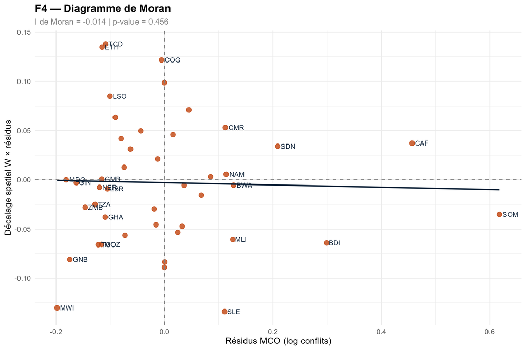

Figure 3: F4 — Diagramme de Moran (résidus MCO)

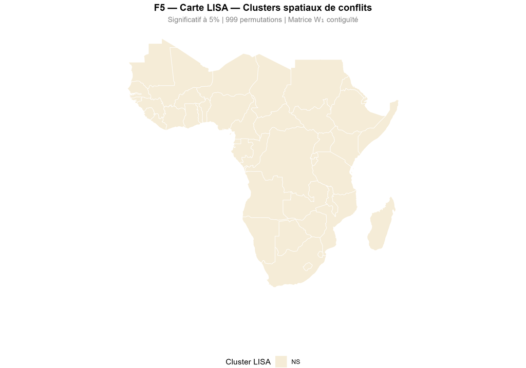

Figure 4: F5 — Carte LISA — Clusters spatiaux de conflits